# Bifurcation or state tipping: assessing transition type in a model trophic cascade

Ryan Batt

2018-07-07

Abstract

The primary purpose of this document is to sketch out the key equations, figures, and numerical results for a manuscript that focuses on assessing whether a model undergoes state-tipping or a bifurcation. Our approach emphasizes reducing the dimensionality of the original model to redefine manipulated state variables as parameters. Thus, when these redefined parameters are manipulated to induce a transition, because they parameters not states, the transition should be viewed as a bifurcation, not state tipping.

# System of Equations & Manipulation

Start with the equations for the ecosystem dynamics:
$$\begin{array}{llr}
\dot{A} &= sJ - qEA - m_AA &(1) \\
\dot{F} &= D_F(F_o - F) - c_{FA}FA &(2)\\
\dot{J} &= fA - c_{JA}JA - \frac{c_{JF}vJF}{h+v+c_{JF}F} - sJ &(3)\\
\dot{H} &= D_H(H_R-H) + \alpha c_{HP}HP - c_{HF}HF &(4)\\
\dot{P} &= r_P L \gamma (I_0,P)P - mP - c_{PH}HP &(5)\\
\end{array}$$
Focusing on the fish, and setting each of the 3 fish differential equations to 0 and solving for the respective state variables:
$$\begin{array}{llr}
A&= \frac{sJ}{qE+m_A} &(6)\\[10pt]
F&=\frac{D_FF_0}{D_F + c_{FA}A} &(7)\\[10pt]
J&=\frac{fA}{c_{JA}A+s+\frac{c_{JF}vF}{h+v+c_{JF}F}} &(8)\\[10pt]
\end{array}$$
**Begin Equations of Motion**
Although our ultimate goal is to see if the equation of motion for $J$ or $F$ shows alternate states, for completeness we will also present the equation of motion for $A$, which is acquired by substituting the RHS of Eq7 for $F$ in Eq8, then substituting the resulting expression for $J$ in Eq1:
$$\begin{array}{llr}
\dot{A} &= sfA\Bigg(c_{JA}A+s+c_{JF}v\bigg(\frac{(h+v)(D_F+c_{FA}A)}{D_F F_o}+c_{JF}\bigg)^{-1}\Bigg)^{-1} -qA -m_A A &(9)
\end{array}$$
To get the equation of motion for $F$, we begin by getting an expression for $A$ that depends only on $F$ and parameters, which is achieved by substituting Eq8 into Eq6 and solving for $A$:
$$\begin{array}{llr}
A&=\bigg({\frac{sfA}{c_{JA}A+s+\frac{c_{JF}vF}{h+v+c_{JF}F}}}\bigg)\bigg(qE+m_A\bigg)^{-1} &(10a)\\[15pt]
sfA &= A(qE+m_A)\big(c_{JA}A+s+\frac{c_{JF}vF}{h+v+c_{JF}F}\big) &(10b)\\[10pt]
sf &=(qE+m_A)\big(c_{JA}A+s+\frac{c_{JF}vF}{h+v+c_{JF}F}\big) &(10c)\\[10pt]
A&=\frac{sf}{c_{JA}(qE+m_A)} - \frac{s}{c_{JA}} - \frac{c_{JF}vF}{c_{JA}(h+v+c_{JF}F)} &(10d)
\end{array}$$
Going from Eq10b to Eq10c is achieved by dividing both sides of the equation by $A$, which implies that in Eq10c $A$ cannot be 0 when $\dot{A}$ is 0. We will return to the consequences of this assumption later as we assess our derived equation of motion for $F$. By subtituting the RHS of Eq10d for $A$ in Eq2, we arrive at the equation of motion for $F$:
$$\begin{array}{llr}
\dot{F} &= D_F(F_o-F) - c_{FA}F(\frac{sf}{c_{JA}(qE+m_A)} - \frac{s}{c_{JA}} - \frac{c_{JF}vF}{c_{JA}(h+v+c_{JF}F)}) &(11)
\end{array}$$

The equation of motion for $J$ can be acquired by substituting the RHS of Eq7 for $F$ in Eq3 ,then exchanging $A$ in that resulting expression for the RHS of Eq6:
$$\begin{array}{llr}
Q &\equiv 1/(qE + m_A) \\
\dot{J} &= fsJQ - c_{JA}sQJ^2 - sJ - \frac{c_{JF}vJ}{\frac{(h+v)}{(D_FF_o)(D_F+c_{FA}sQJ)^{-1}} + c_{JF}} &(12)
\end{array}$$

# Table of Parameter Values

**Table 1.** Model parameters, description, values, and units. Parameters are taken from [@carpenter2008] and [@carpenter2013]. The function describes phytoplankton growth, and can be found in [@carpenter2008].

| Symbol | Description | Quantity | Units |
| --- | --- | --- | --- |
| q | Harvest or stocking | variable | t^{-1} |
| s | Survival rate of juveniles to maturation | 0.6 | t^{-1} |
| m_A | Mortality rate of adults | 0.4 | t^{-1} |
| m | Phytoplankton mortality | 0.1 | t^{-1} |
| f | Fecundity of adult bass | 2 | J/A |
| c_{FA} | Predation of planktivores by adult bass | 0.3 | t^{-1} A^{-1} |
| c_{JA} | Predation of juvenile bass on by adult bass | 0.1 | t^{-1} A^{-1} |
| c_{JF} | Predation of juvenile bass by planktivorous fish | 0.5 | t^{-1} F^{-1} |
| c_{PH} | Predation of phytoplankton by herbivores | 0.25 | t^{-1} H^{-1} |
| c_{HF} | Predation of herbivores by planktivores | 0.1 | t^{-1} F^{-1} |
| F_o | Abundance of planktivorous fish in non-foraging arena | 200 | F |
| H_R | Reservoir of herbivores in a deep-water refuge | 4 | H |
| D_F | Diffusion of planktivores between refuge and foraging arena | 0.09 | t^{-1} |
| DH | Diffusion of between shallow and deep water | 0.5 | t^{-1} |
| v | Rate at which J enter a foraging arena, becoming vulnerable | 80 | t^{-1} |
| h | Rate at which J hide in a refuge | 80 | t^{-1} |
| r_P | Growth rate of phytoplankton | 3 | m^2 mg^{-1} |
| L | Phosphorus loading rate | 0.6 | mg m^{-2} t^{-1} |
|  | Assimilation of phytoplankton phosphorus by zooplankton | 0.3 | g g^{-1} |
|  | Density-dependent phytoplankton growth response to light | n/a | n/a |
| I0 | Solar irradiance incident on the surface of the water | 300 | E m^{-2} s^{-1} |

# Setup

```r
set.seed(42)
qE <- -0.001 #0.02
qE_end <- 0.001#/20 #-5#-0.025

dt <- 0.01 # 0.01
nYears <- 1020#/20

noise_coeff <- c(0.01, 0.01, 0.01, 0.01, 0.01)
```

# Simulation

## Simulate Time series

```r
# set initial values to equilibrium (roots)
X_init <- pmax(bs.tipping::getRoot5D(c(A0=150, F0=50, J0=100, H0=100, P0=500), pars=c(qE=qE)), 1E-3)

# simulate an example of fish
qE_vec <- seq(qE, qE_end, length.out=nYears/dt)
stateMat <- matrix(NA, nrow=nYears/dt, ncol=5, dimnames=list(NULL, c("A0","F0","J0","H0","P0")))
stateMat[1,] <- unlist(X_init)

for(j in 2:nrow(stateMat)){ # iterate through time steps
    state <- stateMat[j-1,]
    dState_dt <- ecoStep(X=state, pars=c(qE=(qE_vec[j])))

    # Euler Method Approximation
    dState <- dState_dt*dt + rnorm(5, sd=c(noise_coeff))*dt
    eulerState <- pmax(state + dState, 1E-3)
    stateMat[j,] <- eulerState # euler
    # stateMat[j,] <- getRoot5D(stateMat[j-1,], pars=c(qE=qE_vec[j]))
}

tsMat <- cbind(time=seq(0, nYears-dt, by=dt), qE=qE_vec, stateMat)
```

## Figure: 5-dimension simulation

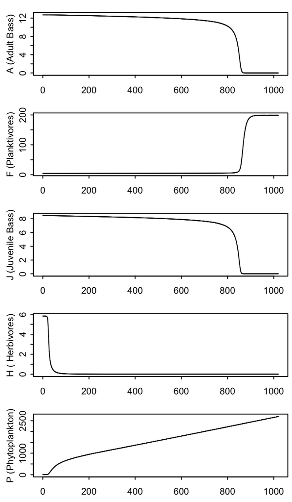

**Figure.** Simulated time series of adult bass (A0), planktivores (F0), and juvenile bass (J0) over a gradient of harvesting of adult bass (qE).

```r
par(mfrow=c(5,1), mar=c(1.5, 2, 0.75, 0.25), ps=8, cex=1, mgp=c(1, 0.25, 0), tcl=-0.15)
stateLabs <- c(
    A0="A (Adult Bass)",
    F0="F (Planktivores)",
    J0="J (Juvenile Bass)",
    H0="H ( Herbivores)",
    P0="P (Phytoplankton)"
)
stateNames <- names(stateLabs)
for(i in 1:length(stateNames)){
    plot(tsMat[,"time"], tsMat[,stateNames[i]], type='l', ylab=stateLabs[stateNames[i]], xlab="")
}
```

# Equations of Motion

## Figure: A Motion

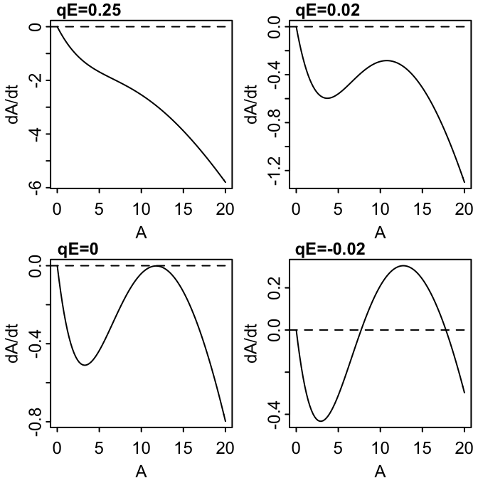

**Figure.** Equation of motion for A.

```r
qevals <- c(0.25, 0.025, 0, -0.025)
par(mfrow=c(2,2), mar=c(1.85,1.85,0.75,0.25), mgp=c(1,0.15,0), tcl=-0.15, ps=9, cex=1)
for(i in 1:length(qevals)){
    curve(stateMotion(state0=x, pars=c(qE=qevals[i])), from=0, to=20, ylab="dA/dt", xlab="A")
    abline(h=0, lty=2)
    mtext(paste0("qE=",round(qevals[i],2)), side=3, line=0, adj=0.05, font=2)
}
```

## Figure: J Motion

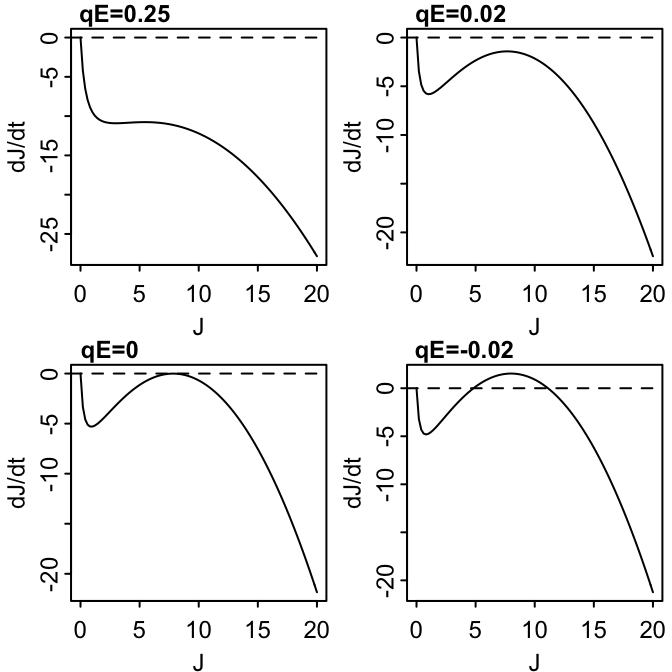

**Figure.** Equation of motion for J.

```r
par(mfrow=c(2,2), mar=c(1.85,1.85,0.75,0.25), mgp=c(1,0.15,0), tcl=-0.15, ps=9, cex=1)
for(i in 1:length(qevals)){
    curve(stateMotion(state0=x, stateVar="J0", pars=c(qE=qevals[i])), from=0, to=20, ylab="dJ/dt", xlab="J")
    abline(h=0, lty=2)
    mtext(paste0("qE=",round(qevals[i],2)), side=3, line=0, adj=0.05, font=2)
}
```

## Figure: F Motion

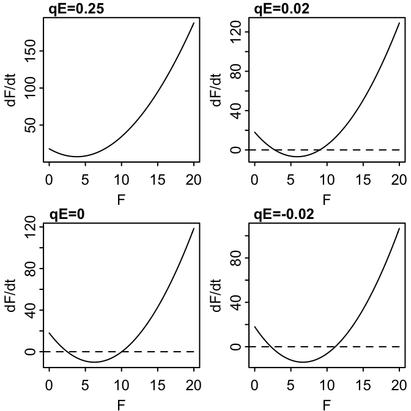

**Figure.** Equation of motion for F.

```r
par(mfrow=c(2,2), mar=c(1.85,1.85,0.75,0.25), mgp=c(1,0.15,0), tcl=-0.15, ps=9, cex=1)
for(i in 1:length(qevals)){
    curve(stateMotion(state0=x, stateVar="F0", pars=c(qE=qevals[i])), from=0, to=20, ylab="dF/dt", xlab="F")
    abline(h=0, lty=2)
    mtext(paste0("qE=",round(qevals[i],2)), side=3, line=0, adj=0.05, font=2)
}
```

Unfortunately, this state variable only shows a trivial stable node and a saddle point. This is the state variable that requires algebra cancelling the ‘A’ state variable in order to get its equation of motion (without A canceling, you cannot get a dF/dt vs F type plot easily [as a function of F and parameters]). We think this result is invalid, as there must be some assumptions in the algebra that invalidate our desired interpretation.

## Figure: Combined A, J, F Motion

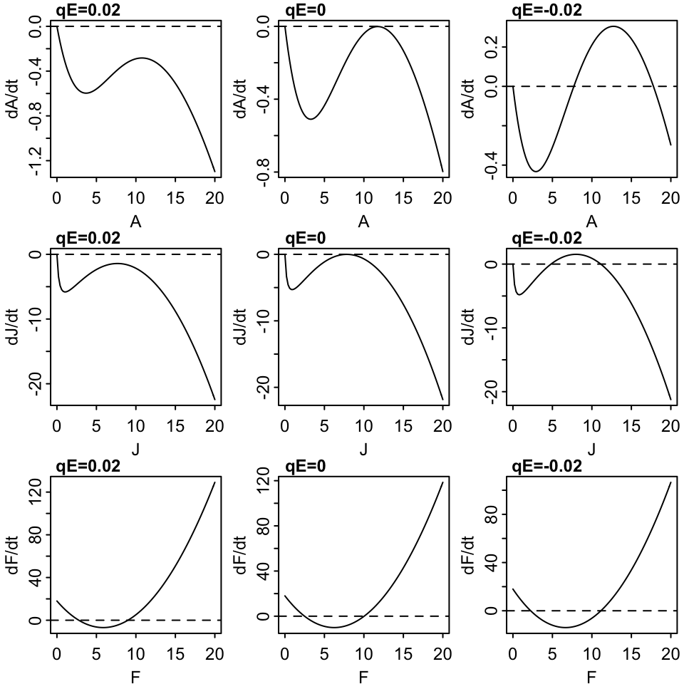

**Figure.** Motion of A, J, and F. Note that the equation of motion for F failed to exhibit alternate states. In formulating the equation for motion of F, there is an algebraic step that requires dropping from terms via division by A, which assume that A≠0. Therefore, states of F that correspond to A=0 are invalid. The equation of motion for A indicates that one of the stable nodes is at A=0, implying that the equation of motion for F is inaccurate in the corresponding region.

```r
xlabs <- c("A","J","F") #ylabs <- c("dA/dt", "dJ/dt", "dF/dt")
ylabs <- paste0("d",xlabs,"/dt")
svars <- paste0(xlabs,"0")
par(mfrow=c(3,3), mar=c(1.85,1.85,0.75,0.25), mgp=c(1,0.15,0), tcl=-0.15, ps=9, cex=1)
for(s in 1:3){
    for(i in 2:length(qevals)){
        curve(stateMotion(state0=x, stateVar=svars[s], pars=c(qE=qevals[i])), from=0, to=20, ylab=ylabs[s], xlab=xlabs[s])
        abline(h=0, lty=2)
        mtext(paste0("qE=",round(qevals[i],2)), side=3, line=0, adj=0.05, font=2)
    }
}
```

## Figure: A Motion A Ball-in-Cup

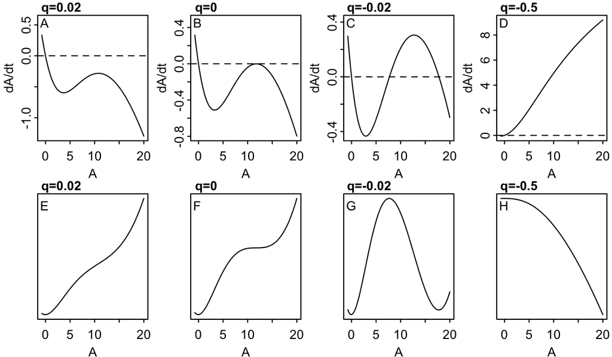

**Figure.** Motion of A, and its integral (ball-in-cup diagram).

```r
Adot <- function(A, pars=c(qE=-0.001)){
    parsF <- unlist(formals(ecoStep)[c("fA", "cJA", "cJF", "cFA", "vuln", "hide", "surv", "Fo", "DF")])
    if(missing(pars)){ # if a function requires qE, pars needs to be supplied (e.g., pars=c(qE=0.1))
        pars <- parsF
    }else{
        pars <- c(pars, parsF[!names(parsF)%in%names(pars)])
    }
    with(as.list(pars),{
        surv*fA*A*( cJA*A+surv+cJF*vuln*( ((hide+vuln)*(DF+cFA*A)) / (DF*Fo)+cJF )^(-1) )^(-1) - qE*A - (mA<-0.4)*A
    })
}
# Avec <- seq(0, 20, length.out=200)
# dAdt_A_vec <- Adot(A=Avec, pars=c(qE=-0.001))
# plot(Avec, dAdt_A_vec, type='l')
# # curve(Adot(A=x, pars=c(qE=-0.001)), from=0, to=20); abline(h=0)
# plot(Avec, cumsum(dAdt_A_vec), type='l')

# Avec <- seq(0, 20, length.out=200)
# qevals2 <- c(qevals[-1], -1)
# par(mfcol=c(2,4), mar=c(1.85,1.85,0.75,0.25), mgp=c(1,0.15,0), tcl=-0.15, ps=9, cex=1)
# l <- 0
# for(q in 1:length(qevals2)){
#   dAdt_A_vec <- Adot(A=Avec, pars=c(qE=qevals2[q]))
#   par(mar=c(1.85,1.85,0.75,0.25))
#   plot(Avec, dAdt_A_vec, type='l', ylab="dA/dt", xlab="A")
#   qlab <- paste0("q=",round(qevals2[q],2))
#   mtext(qlab, side=3, line=0, adj=0.05, font=2)
#   abline(h=0, lty=2)
#   mtext(LETTERS[l<-l+1], side=3, line=-1, adj=0.05)
#
#   par(mar=c(1.0,1.85,1.6,0.25))
#   plot(Avec, -cumsum(dAdt_A_vec), type='l', ylab="", xlab="", xaxt='n', yaxt='n')
#   mtext(qlab, side=3, line=0, adj=0.05, font=2)
#   mtext("A", side=1, line=0)
#   mtext(LETTERS[l<-l+1], side=3, line=-1, adj=0.05)
# }
Avec <- seq(-0.75, 20, length.out=200)
qevals2 <- c(qevals[-1], -0.5)
par(mfrow=c(2,4), mar=c(1.85,1.85,0.75,0.25), mgp=c(1,0.15,0), tcl=-0.15, ps=9, cex=1)
l <- 0
for(q in 1:length(qevals2)){
    dAdt_A_vec <- Adot(A=Avec, pars=c(qE=qevals2[q]))
    qlab <- paste0("q=",round(qevals2[q],2))
    # par(mar=c(1.85,1.85,0.75,0.25))
    ylim <- range(dAdt_A_vec)
    if(ylim[2]<0.5){
        yadj <- diff(ylim)*0.15
        ylim[2] <- ylim[2] + yadj #max(ylim[2], 0.15)
    }
    plot(Avec, dAdt_A_vec, type='l', ylab="dA/dt", xlab="A", ylim=ylim)
    mtext(qlab, side=3, line=0, adj=0.05, font=2)
    abline(h=0, lty=2)
    mtext(LETTERS[l<-l+1], side=3, line=-0.8, adj=0.025)
}
for(q in 1:length(qevals2)){
    dAdt_A_vec <- Adot(A=Avec, pars=c(qE=qevals2[q]))
    qlab <- paste0("q=",round(qevals2[q],2))
    # par(mar=c(1.0,1.85,1.6,0.25))
    plot(Avec, -cumsum(dAdt_A_vec), type='l', ylab="", xlab="A", xaxt='s', yaxt='n')
    mtext(qlab, side=3, line=0, adj=0.05, font=2)
    # mtext("A", side=1, line=0)
    mtext(LETTERS[l<-l+1], side=3, line=-1, adj=0.025)
}
```

# Figure: Bifurcation Diagram

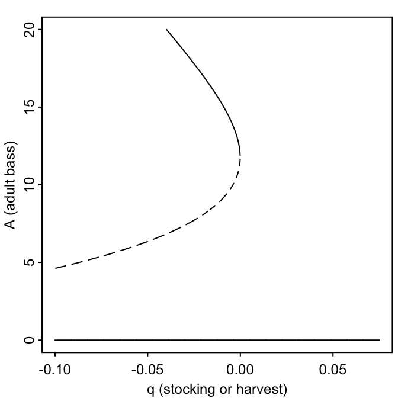

**Figure.** Bifurcation diagram. Solid line is a stable state. Dashed line is an unstable state.

```r
qe_range <- c(0.075,-0.1) # range of q values
qevec_bd <- do.call(seq, c(as.list(qe_range),length=2E3)) # sequence of q values
rts <- vector('list',length=length(qevec_bd)) # empty list to store roots for each q value
for(q in 1:length(qevec_bd)){ # for each val of q
    tq <- qevec_bd[q] # temp q value
    trts <- rootSolve::uniroot.all(f=Adot, interval=c(0,20), pars=c(qE=tq)) # temp roots
    rts[[q]] <- trts # store temp root
    tclasses <- vector('character', length=length(trts))
    for(r in 1:length(trts)){ # for each root found for this val of q
        trt <- trts[r] # temp root
        t_perturb <- max(0.01*trt, 0.01)
        resp_neg <- Adot(trt-t_perturb, pars=c(qE=tq))
        resp_pos <- Adot(trt+t_perturb, pars=c(qE=tq))
        if(resp_neg>0 & resp_pos<0){ # crosses 0 line downward
            tclass <- 'snode'
        }else if(sign(resp_neg)==sign(resp_pos)){ # barely touches 0 line
            tclass <- 'unode'
        }else if(resp_neg<0 & resp_pos>0){# cross 0 line upward; could have combined with above, but might want to separate later
            tclass <- 'unode'
        }
        tclasses[r] <- tclass
    }
    names(rts[[q]]) <- tclasses
}
# names(rts) <- paste0('q',round(qevec_bd,4))
get_bb <- function(x)min(x[names(x)%in%'snode'])
get_ub <- function(x){
    snode_ind <- names(x)%in%'snode'
    if(sum(snode_ind)>1){
        return(unname(max(x[snode_ind])))
    }else{
        return(NA)
    }
}
get_separatrix <- function(x){
    unode_ind <- names(x)%in%'unode'
    if(any(unode_ind)){
        return(unname(x[unode_ind]))
    }else{
        return(NA)
    }
}
bot_branch <- sapply(rts, get_bb)
upper_branch <- sapply(rts, get_ub)
separatrix <- sapply(rts, get_separatrix)
ylim <- range(c(bot_branch, upper_branch, separatrix), na.rm=TRUE)
# xlim <- rev(range(qevec_bd))
# plot(qevec_bd, bot_branch, ylim=ylim, xlim=xlim, type='l')
par(mar=c(2,1.85,0.75,0.25), mgp=c(1,0.15,0), tcl=-0.15, ps=9, cex=1)
plot(qevec_bd, bot_branch, ylim=ylim, type='l', ylab="A (adult bass)", xlab='q (stocking or harvest)')
lines(qevec_bd, upper_branch, lty=1)
lines(qevec_bd, separatrix, lty=2)
```

# Session Info

```r
difftime(Sys.time(), t1) # how long it took to run these models/ produce this report
```

```
## Time difference of 28.5 secs
```

```r
Sys.time()
```

```
## [1] "2018-07-13 20:25:37 EDT"
```